# Which of my customers are similar?

Olga Lalakulich olalakul@gmail.com

You (The [Wholesale Customer Dataset](https://archive.ics.uci.edu/ml/datasets/Wholesale+customers) from UCI Machine Learning Repository[^1]) are a wholesale distributor in 3 regions: “Oporto” with 47 customers, “Lisbon” with 77 customers and “Other” with 316 customers, among them 298 are from the “Cafe” (including Hotels and Restaurants) distribution channel and 142 from “Retail”.

Here is few rows from your annual revenue dataset:

| Channel | Region | Fresh | Milk | Grocery | Frozen | Detergents_Paper | Delicassen |
| --- | --- | --- | --- | --- | --- | --- | --- |
| Retail | Other | 12669 | 9656 | 7561 | 214 | 2674 | 1338 |
| Retail | Other | 7057 | 9810 | 9568 | 1762 | 3293 | 1776 |
| Retail | Other | 6353 | 8808 | 7684 | 2405 | 3516 | 7844 |
| Cafe | Other | 13265 | 1196 | 4221 | 6404 | 507 | 1788 |
| Retail | Other | 22615 | 5410 | 7198 | 3915 | 1777 | 5185 |
| Retail | Other | 9413 | 8259 | 5126 | 666 | 1795 | 1451 |

Here is how many customers with a specific revenue range for each product for each “Cafe” or “Retail” group you have

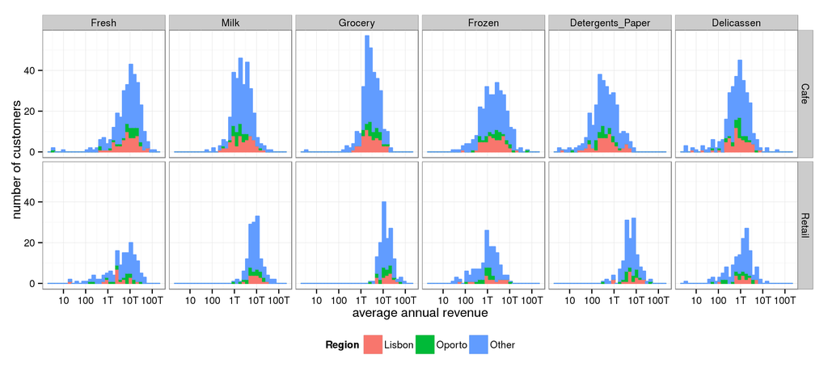

We immediately see that typical revenues are different for diffrent products. For some products typical revenues are different for “Retail” and “Cafe” distribution channels.

#### What is the main difference between customers?

The evident difference between our customers is total revenue. Can be go beyond that and seach for more subtle differences? We pay attention to the difference between the revenue for the corresponding product and its typical scale.

#### Which of my custimers are similar?

We visualize similarity based on individual product categories (Fresh, Milk, Grocery, Frozen, Detergents, Delicassen) without explicit accounting for Total revenue and Channel. Similarity takes into account absolute and relative amounts of each product category. Notice that

- Retail and Cafe customers are mostly automatically separated
- Large, medium and low revenues are mostly automatically clustered

[interactive chart not shown]

The qualitative interpretation of individual clusters can be inferred by interactive examination of each point. Drag or zoom the picture for better resolution. Notice that

### Contact: Olga Lalakulich olalakul@gmail.com

### References

[^1]: https://archive.ics.uci.edu/ml/datasets/Wholesale+customers The data set is originated from a larger database referred on: Abreu, N. (2011). Analise do perfil do cliente Recheio e desenvolvimento de um sistema promocional. Mestrado em Marketing, ISCTE-IUL, Lisbon